# STAT 467-Recitation 8

## Reminder and Notes

Last class,

- How to apply PCA in R.
- How to apply Factor analysis in R.

For more details [visit](https://ozancanozdemir.shinyapps.io/s467r7/)

**HAPPY NEW YEAR!**

[figure not shown]

In this class, we’ll use

```
library(CCA)
library(CCP)
library(caret)
library(ISLR)
library(corrplot)
library(pROC)
library(tidyverse)
library(mlbench)
library(e1071)
```

## Canonical Correlation Analysis (CCA)

Canonical correlation analysis (CCA) is a a class of multivariate statistical analysis technique which operates on the same principle as the principal component analysis. The main purpose of the canonical correlation approach is the exploration of sample correlations between two sets of quantitative variables observed on the **same or similar** experimental units. Canonical correlation analysis determines a set of canonical variates, orthogonal linear combinations of the variables within each set that best explain the variability both within and between sets.

**There is a small difference between CCA and PCA**

- CCA is used to correlate simultaneously several metric dependent variables and several metric independent variables measured on or observed on the same experimental units.
- On the other hand, PCA method deals with one data set only and it tries to to reduce the overall dimensionality of the dataset using some linear combination of the initial variables.
- The technique is an extension of multiple correlation analysis and is often applicable in the same situations in which multivariate regression analysis methods would be applicable.

Before we get started with the analysis in R, lets review some concepts related to Canonical correlation analysis.

**Purpose of Canonical Correlation Analysis**

*Data Reduction*

Canonical correlation analysis provides a way for explaining the relationship between 2 sets of variables using linear combinations of these variables.

*Data interpretation*

This multivariate analysis technique is also of particular interest when it comes to finding features (canonical variates) that are statistically significant in terms of explaining the covariance between the given sets of variables.

**Properties of Canonical Correlations**

Canonical correlations are invariant to changes of scale on either the response variables ($ys$) and the explanatory variables ($xs$).In other words, changing the scale of measurement of the 2 sets of variables of interest in the analysis, for instance, from inches to centimeters does not interfere with the canonical correlations that follow.

Also, the first canonical correlation ($r_1$) is the maximum correlation between the linear functions of $Y$ and $X$. In other words, $r_1$ exceeds the (absolute) simple correlation between any $Y$ and any $X$ or the multiple correlation between any $Y$ and all the $Xs$ or between any $X$ and all the $Ys.$

**Canonical Correlation Analysis using R**

**Example 1**

In this class, we will consider red wine quality data set which is available on UCI ML Repository. Here is the [data](https://github.com/okutse/data/blob/master/trial_data.csv)

The original data set has 1600 observations measured on 12 variables, but some of them were dropped for this tutorial. (Just for an ease.)

```r
data<-read.csv("trial_data.csv",header=T)
head(data)
```

```
##   chlorides free.sulfur.dioxide total.sulfur.dioxide fixed.acidity
## 1     0.076                  11                   34           7.4
## 2     0.098                  25                   67           7.8
## 3     0.092                  15                   54           7.8
## 4     0.075                  17                   60          11.2
## 5     0.076                  11                   34           7.4
## 6     0.075                  13                   40           7.4
##   volatile.acidity citric.acid density
## 1             0.70        0.00  0.9978
## 2             0.88        0.00  0.9968
## 3             0.76        0.04  0.9970
## 4             0.28        0.56  0.9980
## 5             0.70        0.00  0.9978
## 6             0.66        0.00  0.9978
```

We separated the existing columns into two groups to conduct CCA.

- set 1(che) consists of 3 variables chlorides , free.sulfur.dioxideand total.sulfur.dioxide
- set 2 (acidity) consists of 4 variables fixed.acidity, volatile.acidity citric.acid and density

In this analysis, our interest is in determining the number of dimensions (canonical variables) that are significant in explaining the association between the 2 sets of variables.

```r
che<-data[,1:3]
acidity<-data[,4:7]
```

Next, we load all the required packages to facilitate the analysis and use the `matcor()` from the `CCA` package to check out the between and within set associations.

[output not shown]

```r
round(cormat$Xcor, 4)
```

```
##                      chlorides free.sulfur.dioxide total.sulfur.dioxide
## chlorides               1.0000              0.0056               0.0474
## free.sulfur.dioxide     0.0056              1.0000               0.6677
## total.sulfur.dioxide    0.0474              0.6677               1.0000
```

The associations between the two sets can be extracted as;

```r
#between set associations
round(cormat$XYcor, 4)
```

```
##                      chlorides free.sulfur.dioxide total.sulfur.dioxide
## chlorides               1.0000              0.0056               0.0474
## free.sulfur.dioxide     0.0056              1.0000               0.6677
## total.sulfur.dioxide    0.0474              0.6677               1.0000
## fixed.acidity           0.0937             -0.1538              -0.1132
## volatile.acidity        0.0613             -0.0105               0.0765
## citric.acid             0.2038             -0.0610               0.0355
## density                 0.2006             -0.0219               0.0713
##                      fixed.acidity volatile.acidity citric.acid density
## chlorides                   0.0937           0.0613      0.2038  0.2006
## free.sulfur.dioxide        -0.1538          -0.0105     -0.0610 -0.0219
## total.sulfur.dioxide       -0.1132           0.0765      0.0355  0.0713
## fixed.acidity               1.0000          -0.2561      0.6717  0.6680
## volatile.acidity           -0.2561           1.0000     -0.5525  0.0220
## citric.acid                 0.6717          -0.5525      1.0000  0.3649
## density                     0.6680           0.0220      0.3649  1.0000
```

Next, we are going to obtain the canonical correlations from which we will then extract the raw canonical coefficients. Interpretations of the raw canonical coefficients will then be made.

```r
#obtaining the canonical correlations
 can_cor1=cc(che,acidity)
 can_cor1$cor
```

```
## [1] 0.45361635 0.20703957 0.06092621
```

Instead of the interpretation of canonical correlation, we will prefer their squared values.

```r
( can_cor1$cor^2)
```

```
## [1] 0.205767792 0.042865382 0.003712003
```

We see that 21% of the variation in $U_1$ is explained by the variation in $Y_1$ , and 4% of the variation in $U_2$ is explained by $V_2$, but only 0.3% of the variation in $U_3$ is explained by $v_3$ . We can say that there is no strong association between chemical and asidity.

The raw canonical coefficients can be obtained from can_cor1 as;

```r
#raw canonical coefficients
 can_cor1[3:4]
```

```
## $xcoef
##                              [,1]         [,2]         [,3]
## chlorides            -15.40227312  6.022271042 -13.39830038
## free.sulfur.dioxide    0.04039044 -0.081896302  -0.09040281
## total.sulfur.dioxide  -0.02578993 -0.004526871   0.03142581
##
## $ycoef
##                          [,1]         [,2]          [,3]
## fixed.acidity       0.6300078    0.7382125    0.04156297
## volatile.acidity   -3.7269496    2.7250334    5.25358495
## citric.acid        -6.6286891    0.6789206    0.75975488
## density          -382.1226185 -319.7329865 -344.27947229
```

The interpretation of the raw canonical coefficients follows in a way that is similar to the interpretation of the coefficients of the linear regression models.

For instance, consider the acidity set of variables. Suppose that we wanted an interpretation of the influence of fixed.acidity on the first canonical variate for the set in question, the interpretation would be as follows:

A one unit increase in fixed.acidity would result in an increase of 0.63 units in the value of the first canonical variate for the acidity set of variables, when the other variables are held constant. Furthermore, volatile acidity would result in an increase of about 2.72 units in the second dimension of the canonical variate.

Using the CCA package one can also take an advantage of nice graphical tools which are available for the canonical correlation analysis. The idea is to display maximized correlations between transformed variables of the dataset X (che) and the dataset Y (acidity).

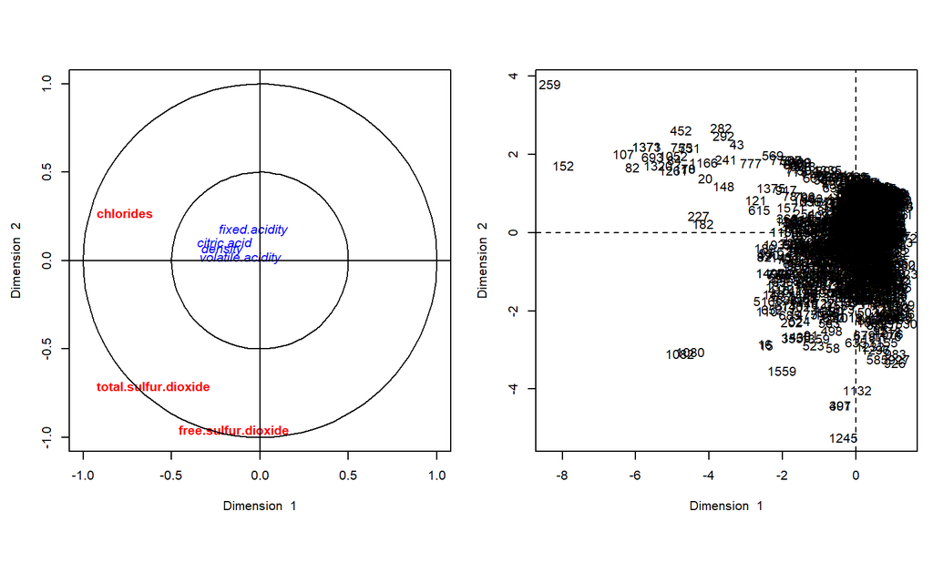

```r
plt.cc(can_cor1, var.label = TRUE)
```

In the following chunk of code, we will implement the `comput` function to compute the correlations between the variables and the canonical variates (also the loadings of the variables on the canonical dimensions).

Usually, the number of canonical dimensions the same as the count of variables in the smaller set. The number of canonical dimensions that are significant in explaining the relationship between the 2 sets of variables may, however, be smaller than the number of variables in the smaller data set. In this case, there are 3 dimensions.

```r
#computes the canonical loadings
 can_cor2=comput(che,acidity,can_cor1)
 can_cor2[3:6] #displays the canonical loadings
```

```
## $corr.X.xscores
##                            [,1]       [,2]       [,3]
## chlorides            -0.7627757  0.2716167 -0.5868540
## free.sulfur.dioxide  -0.1479687 -0.9544958 -0.2589267
## total.sulfur.dioxide -0.6006467 -0.7074330  0.3725079
##
## $corr.Y.xscores
##                        [,1]       [,2]        [,3]
## fixed.acidity    -0.0368851 0.17516149 -0.03066069
## volatile.acidity -0.1137480 0.01498495  0.05033043
## citric.acid      -0.2036616 0.10471705 -0.03413442
## density          -0.2151756 0.06505414 -0.03208948
##
## $corr.X.yscores
##                             [,1]       [,2]        [,3]
## chlorides            -0.34600754  0.0562354 -0.03575479
## free.sulfur.dioxide  -0.06712102 -0.1976184 -0.01577542
## total.sulfur.dioxide -0.27246318 -0.1464666  0.02269549
##
## $corr.Y.yscores
##                         [,1]       [,2]       [,3]
## fixed.acidity    -0.08131343 0.84602907 -0.5032430
## volatile.acidity -0.25075819 0.07237725  0.8260885
## citric.acid      -0.44897316 0.50578277 -0.5602585
## density          -0.47435584 0.31421115 -0.5266942
```

To obtain the statistical significance of the dimensions, we are going to use the loaded `CCP` package. The code and output is as follows

```r
#test of canonical dimensions
 rho=can_cor1$cor
##defining the number of observations, no of variables in first set,
 #and number of variables in second set
 n=dim(che)[1]
 p=length(che)
 q=length(acidity)
 ##Calculating the F approximations using different test statistics
 #using wilks test statistic
 p.asym(rho,n,p,q,tstat="Wilks")
```

```
## Wilks' Lambda, using F-approximation (Rao's F):
##               stat    approx df1      df2      p.value
## 1 to 3:  0.7573653 38.878017  12 4212.328 0.000000e+00
## 2 to 3:  0.9535817 12.770396   6 3186.000 2.675637e-14
## 3 to 3:  0.9962880  2.969489   2 1594.000 5.161358e-02
```

The above results are from using the Wilks test statistic. These results may vary slightly depending on the test statistic implemented.

Lastly, the last test determines the significance of the 3rd dimension, which is not statistically significant in this case since $p>0.05.$

**Precautions when using Canonical Correlations**

- The sample size involved should be of a relatively large size. The technique works best with larger sample sizes.
- The variables should follow a multivariate normal distribution since canonical correlations assume that the joint distribution of X and Y is multivariate normal. (Hard to assess.)
- Samples used should be representative of the populations in question.

## Classification Problem

In the data science, the researchers are interested in two types of problems. The first one is regression assuming that the response variable $Y$ is quantitative. The second problem, on the other hand, deals with the response variable is qualitative. For example, eye color is qualitative, taking qualitative on values blue, brown, or green. Often qualitative variables are referred to as categorical ; we will use these terms interchangeably. Such problem is called **classification** problem.

In classification problems, we study approaches for predicting qualitative responses, a process that is known as classification. Predicting a qualitative response for an observation can be referred to as classifying that observation, since it involves assigning the observation to a category, or class. On the other hand, often the methods used for classification first predict the probability of each of the categories of a qualitative variable, as the basis for making the classification. In this sense they also behave like regression methods.

There are many possible classification techniques, or classifiers, that one classifier might use to predict a qualitative response. We touched on some of these in class, Logistic Regression and Naive Bayes Classifier.

Just as in the regression setting, in the classification setting we have a set of training observations $(x_1, y_1),\dots , (x_n, y_n)$ that we can use to build a classifier. We want our classifier to perform well not only on the training data, but also on test observations that were not used to train the classifier.

### Logistic Regression

Logistic regression, also called a logit model, is used to model dichotomous outcome variables. In other words, it is used to model binary response ( 0 and 1). In the logit model the log odds of the outcome is modeled as a linear combination of the predictor variables.

**Example**

We use `Default` dataset from `ISLR` package.

```r
library(ISLR)
head(Default)
```

```
##   default student   balance    income
## 1      No      No  729.5265 44361.625
## 2      No     Yes  817.1804 12106.135
## 3      No      No 1073.5492 31767.139
## 4      No      No  529.2506 35704.494
## 5      No      No  785.6559 38463.496
## 6      No     Yes  919.5885  7491.559
```

After this, we should divide our dataset as train and test to check the validity of the model.

```r
set.seed(42)
default_idx = sample(nrow(Default), 5000) #produce index number for train data
default_trn = Default[default_idx, ]
default_tst = Default[-default_idx, ]
```

We use logistic regression to better estimate the following probability

$$p(x) = P(Y = 1 \mid {X = x})$$
The general form of model is written as follows

$$\log\left(\frac{p(x)}{1 - p(x)}\right) = \beta_0 + \beta_1 x_1 + \beta_2 x_2 + \cdots + \beta_p x_p.$$

Rearranging, we see the probabilities can be written as

$$p(x) = \frac{1}{1 + e^{-(\beta_0 + \beta_1 x_1 + \beta_2 x_2 + \cdots + \beta_p x_p)}} = \sigma(\beta_0 + \beta_1 x_1 + \beta_2 x_2 + \cdots + \beta_p x_p)$$

Notice, we use the sigmoid function as shorthand notation, which appears often in deep learning literature. It takes any real input, and outputs a number between 0 and 1. How useful! (This is actualy a particular sigmoid function called the logistic function, but since it is by far the most popular sigmoid function, often sigmoid function is used to refer to the logistic function)

$$\sigma(x) = \frac{e^x}{1 + e^x} = \frac{1}{1 + e^{-x}}$$

The model is fit by numerically maximizing the likelihood, which we will let `R` take care of.

**Simple Logistic Regression**

We start with a single predictor example, again using `balance` as our single predictor.

Fitting this model looks very similar to fitting a simple linear regression. Instead of `lm()` we use `glm()`. The only other difference is the use of `family = "binomial"` which indicates that we have a two-class categorical response. Using `glm()` with `family = "gaussian"` would perform the usual linear regression.

```r
model_glm = glm(default ~ balance, data = default_trn, family = "binomial")
```

After fitting the model, lets see its summary.

```r
summary(model_glm)
```

```
##
## Call:
## glm(formula = default ~ balance, family = "binomial", data = default_trn)
##
## Deviance Residuals:
##     Min       1Q   Median       3Q      Max
## -2.2621  -0.1506  -0.0610  -0.0235   3.7296
##
## Coefficients:
##               Estimate Std. Error z value Pr(>|z|)
## (Intercept) -1.049e+01  4.981e-01  -21.07   <2e-16 ***
## balance      5.425e-03  3.049e-04   17.79   <2e-16 ***
## ---
## Signif. codes:  0 '***' 0.001 '**' 0.01 '*' 0.05 '.' 0.1 ' ' 1
##
## (Dispersion parameter for binomial family taken to be 1)
##
##     Null deviance: 1483.83  on 4999  degrees of freedom
## Residual deviance:  820.11  on 4998  degrees of freedom
## AIC: 824.11
##
## Number of Fisher Scoring iterations: 8
```

We start to check the significance of the model. For this purpose the following hypothesis is conducted and null and residual deviance values are used. Then, this difference is compared to chi-square statistic with dof 2.

$H_0$= $\beta_0$=$\beta_1$=0 vs $H_1$= At least one of them is different.

```r
ifelse ((1483.83-820.11)< qchisq(0.95,2),print("Fail to Reject Ho"),print("Reject Ho"))
```

```
## [1] "Reject Ho"
```

```
## [1] "Reject Ho"
```

The next thing we should understand is how the `predict()` function works with `glm()`. So, lets look at some predictions.

```r
head(predict(model_glm))
```

```
##      2369      5273      9290      1252      8826       356
## -5.376670 -4.875653 -5.018746 -4.007664 -6.538414 -6.601582
```

By default, `predict.glm()` uses `type = "link"`.

```r
head(predict(model_glm, type = "link"))
```

```
##      2369      5273      9290      1252      8826       356
## -5.376670 -4.875653 -5.018746 -4.007664 -6.538414 -6.601582
```

That is, `R` is returning

$$\hat{\beta}_0 + \hat{\beta}_1 x_1 + \hat{\beta}_2 x_2 + \cdots + \hat{\beta}_p x_p$$
for each observation.

Importantly, these are **not** predicted probabilities. To obtain the predicted probabilities

$$\hat{p}(x) = \hat{P}(Y = 1 \mid X = x)$$

we need to use `type = "response"`

```r
head(predict(model_glm, type = "response"))
```

```
##        2369        5273        9290        1252        8826         356
## 0.004601914 0.007572331 0.006569370 0.017851333 0.001444691 0.001356375
```

Note that these are probabilities, **not** classifications. To obtain classifications, we will need to compare to the correct cutoff value with an `ifelse()` statement.

```r
#model_glm_pred = ifelse(predict(model_glm, type = "link") > 0, "Yes", "No")
model_glm_pred = ifelse(predict(model_glm, type = "response") > 0.5, "Yes", "No")
```

The line that is run is performing

$$\hat{C}(x) =
\begin{cases}
1 & \hat{p}(x) > 0.5 \\
0 & \hat{p}(x) \leq 0.5
\end{cases}$$

where

$$\hat{p}(x) = \hat{P}(Y = 1 \mid X = x).$$

The commented line, which would give the same results, is performing

$$\hat{C}(x) =
\begin{cases}
1 & \hat{f}(x) > 0 \\
0 & \hat{f}(x) \leq 0
\end{cases}$$

where

$$\hat{f}(x) =\hat{\beta}_0 + \hat{\beta}_1 x_1 + \hat{\beta}_2 x_2 + \cdots + \hat{\beta}_p x_p.$$

Once we have classifications, we can calculate metrics such as the trainging classification error rate.

```r
calc_class_err = function(actual, predicted) {
  mean(actual != predicted)
}
```

```r
calc_class_err(actual = default_trn$default, predicted = model_glm_pred)
```

```
## [1] 0.0284
```

As you see, the classification error rate for train data is approximately 3%, which is OK. In addition to this metric, we should consider accuracy, sensitivity and specificty which are obtained from confusion matrix.

One can make a confusion matrix to summarize them

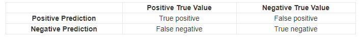

Sensitivity, specificity and accuracy are described in terms of TP, TN, FN and FP.

**Sensitivity = TP/(TP + FN) = (Number of true positive assessment)/(Number of all positive assessment)**

**Specificity = TN/(TN + FP) = (Number of true negative assessment)/(Number of all negative assessment)**

**Accuracy = (TN + TP)/(TN+TP+FN+FP) = (Number of correct assessments)/Number of all assessments)**

As suggested by above equations, sensitivity is the proportion of true positives that are correctly identified by a diagnostic test. It shows how good the test is at detecting a disease.

Specificity is the proportion of the true negatives correctly identified by a diagnostic test. It suggests how good the test is at identifying normal (negative) condition.

Accuracy is the proportion of true results, either true positive or true negative, in a population. It measures the degree of veracity of a diagnostic test on a condition.

We wish to have a model with high sensitivity, specificity and accuracy. (greater than 0.8)

To calculate them in R quickly, the `table()` and `confusionMatrix()` functions can be used.

```r
train_tab = table(predicted = model_glm_pred, actual = default_trn$default)
library(caret)
train_con_mat = confusionMatrix(train_tab, positive = "Yes")
c(train_con_mat$overall["Accuracy"],
  train_con_mat$byClass["Sensitivity"],
  train_con_mat$byClass["Specificity"])
```

```
##    Accuracy Sensitivity Specificity
##   0.9716000   0.2941176   0.9954451
```

As you see, we have high accuracy and specificity, but low sensitivity. However, these are not enough for talking about the goodness of the model because these metrics are calculated for traning case, not test case.

Now, lets calculate them for the test case.

```r
model_glm_pred_test= ifelse(predict(model_glm, type = "response",newdata = default_tst) > 0.5, "Yes", "No")
#As you see we use newdata argument that equals to test data
```

```r
test_tab = table(predicted = model_glm_pred_test, actual = default_tst$default)
library(caret)
test_con_mat = confusionMatrix(test_tab, positive = "Yes")
c(test_con_mat$overall["Accuracy"],
  test_con_mat$byClass["Sensitivity"],
  test_con_mat$byClass["Specificity"])
```

```
##    Accuracy Sensitivity Specificity
##   0.9730000   0.3128834   0.9952450
```

As you see, we have high accuracy and specificity, but low sensitivity.

**Multiple Logistic Regression**

If we include more than one predictors in the model, the way used is called multiple logistic regression model. Before the model, lets examine the relationship between predictors to avoid of multicollinearity problem.

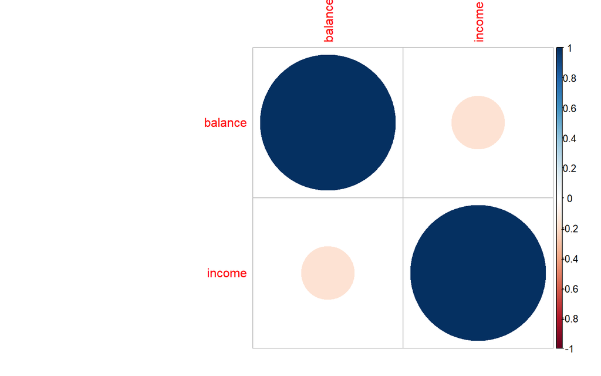

```r
library(corrplot)
correlations <- cor(default_trn[,3:4])
corrplot(correlations, method="circle")
```

As you see, there is no strong association between predictors. That means there is no mutlicollinearity problem.

```r
model_glm_multi = glm(default ~ ., data = default_trn, family = "binomial")
```

After fitting the model, lets see its summary.

```r
summary(model_glm_multi)
```

```
##
## Call:
## glm(formula = default ~ ., family = "binomial", data = default_trn)
##
## Deviance Residuals:
##     Min       1Q   Median       3Q      Max
## -2.4224  -0.1467  -0.0589  -0.0221   3.7105
##
## Coefficients:
##               Estimate Std. Error z value Pr(>|z|)
## (Intercept) -1.052e+01  6.677e-01 -15.763   <2e-16 ***
## studentYes  -6.790e-01  3.223e-01  -2.107   0.0352 *
## balance      5.616e-03  3.171e-04  17.713   <2e-16 ***
## income      -4.771e-07  1.126e-05  -0.042   0.9662
## ---
## Signif. codes:  0 '***' 0.001 '**' 0.01 '*' 0.05 '.' 0.1 ' ' 1
##
## (Dispersion parameter for binomial family taken to be 1)
##
##     Null deviance: 1483.8  on 4999  degrees of freedom
## Residual deviance:  809.0  on 4996  degrees of freedom
## AIC: 817
##
## Number of Fisher Scoring iterations: 8
```

We start to check the significance of the model. For this purpose, the following hypothesis is conducted and null and residual deviance values are used to test. Then, the difference between null and residual deviance is compared to chi-square statistic with degrees of freedom 4 because 4 represents the number of parameters that we tested.

$H_0$= $\beta_0$=$\beta_1$=$\beta_2$=$\beta_3$=0 vs $H_1$= At least one of them is different.

```r
ifelse ((1483.83-809)< qchisq(0.95,4),print("Fail to Reject Ho"),print("Reject Ho"))
```

```
## [1] "Reject Ho"
```

```
## [1] "Reject Ho"
```

As you see the model is significant on the averge.

Now, lets calculate the performance metrics for the test data.

```r
model_glm_pred_test= ifelse(predict(model_glm_multi, type = "response",newdata = default_tst) > 0.5, "Yes", "No")
#As you see we use newdata argument that equals to test data
```

In this code, 0.5 is the cut-off value generally used in the literature. As stated before, we estimate the probabilities by using predict function. Then, we say that if the estimated probability is greater than the defined cut-off value, then it is coded as 1 or Yes. Otherwise, it is zero.

```r
test_tab = table(predicted = model_glm_pred_test, actual = default_tst$default)
library(caret)
test_con_mat = confusionMatrix(test_tab, positive = "Yes")
c(test_con_mat$overall["Accuracy"],
  test_con_mat$byClass["Sensitivity"],
  test_con_mat$byClass["Specificity"])
```

```
##    Accuracy Sensitivity Specificity
##   0.9742000   0.3251534   0.9960719
```

As you see, we have high accuracy and specificity, but low sensitivity. However, we can say that our model can be OK on the average.

Here, I would like to mention an important issue, cut-off point.

lets use different cut-off points and see the performance of the model. In other words, lets obtain predictions using a low, medium, and high cutoff. (0.1, 0.5, and 0.9)

**For 0.1**

```r
model_glm_pred_test_0.1= ifelse(predict(model_glm_multi, type = "response",newdata = default_tst) > 0.1, "Yes", "No")
#As you see we use newdata argument that equals to test data
```

```r
test_tab = table(predicted = model_glm_pred_test_0.1, actual = default_tst$default)
library(caret)
test_con_mat = confusionMatrix(test_tab, positive = "Yes")
c(test_con_mat$overall["Accuracy"],
  test_con_mat$byClass["Sensitivity"],
  test_con_mat$byClass["Specificity"])
```

```
##    Accuracy Sensitivity Specificity
##   0.9346000   0.7361963   0.9412859
```

**For 0.5**

```r
model_glm_pred_test_0.5= ifelse(predict(model_glm_multi, type = "response",newdata = default_tst) > 0.5, "Yes", "No")
#As you see we use newdata argument that equals to test data
```

```r
test_tab = table(predicted = model_glm_pred_test_0.5, actual = default_tst$default)
library(caret)
test_con_mat = confusionMatrix(test_tab, positive = "Yes")
c(test_con_mat$overall["Accuracy"],
  test_con_mat$byClass["Sensitivity"],
  test_con_mat$byClass["Specificity"])
```

```
##    Accuracy Sensitivity Specificity
##   0.9742000   0.3251534   0.9960719
```

**For 0.9**

```r
model_glm_pred_test_0.9= ifelse(predict(model_glm_multi, type = "response",newdata = default_tst) > 0.9, "Yes", "No")
#As you see we use newdata argument that equals to test data
```

```r
test_tab = table(predicted = model_glm_pred_test_0.9, actual = default_tst$default)
library(caret)
test_con_mat = confusionMatrix(test_tab, positive = "Yes")
c(test_con_mat$overall["Accuracy"],
  test_con_mat$byClass["Sensitivity"],
  test_con_mat$byClass["Specificity"])
```

```
##    Accuracy Sensitivity Specificity
##  0.96860000  0.03680982  1.00000000
```

As you see the model gives its best for the value of 0.5. So, we obtained several performance measure values for different cut-off value, but how we can be sure about the performance of our model.

For this purpose, we use **AUC-ROC Curve.**

**What is AUC - ROC curve?**

AUC - ROC curve is a performance measurement for classification problem at various thresholds settings. ROC is a probability curve and AUC represents degree or measure of separability. It tells how much model is capable of distinguishing between classes. Higher the AUC, better the model is at predicting 0s as 0s and 1s as 1s.

To draw this curve, we can consider `pROC` package.

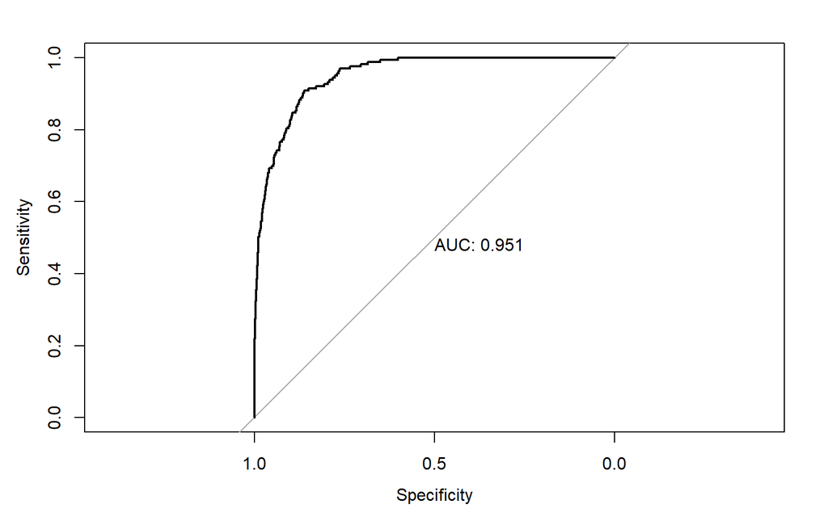

```r
library(pROC)
test_prob=predict(model_glm_multi, type = "response",newdata = default_tst)
test_roc = roc(default_tst$default ~ test_prob, plot = TRUE, print.auc = TRUE)
```

```r
as.numeric(test_roc$auc)
```

```
## [1] 0.9510306
```

$TPR=Sensitivity$

$FPR= 1-Specificity$

A good model will have a high AUC, that is as often as possible a high sensitivity and specificity. That means the model that we fit is defined as a good model due to high AUC value.

**Multinomial Logistic Regression**

What if the response contains more than two categories? For that we need multinomial logistic regression.

$$P(Y = k \mid { X = x}) = \frac{e^{\beta_{0k} + \beta_{1k} x_1 + \cdots + + \beta_{pk} x_p}}{\sum_{g = 1}^{G} e^{\beta_{0g} + \beta_{1g} x_1 + \cdots + \beta_{pg} x_p}}$$

### Naive Bayes Classifier

Naive Bayes is a supervised learning algorithm based on very famous probability theorem, Bayes Theorem, and was developed to solve **classification** problem. The method requires a strong independence among predictor variables. It means that the classification model depends on uncorrelated variables. Here is the some area where Naive Bayes is very popular:

- email filtering
- spam detection
- document categorization

Although it is often outperformed by other techniques, and despite the naÃ¯ve design and oversimplified assumptions, this classifier can perform well in many complex real-world problems. And since it is a resource efficient algorithm that is fast and scales well, it is definitely a machine learning algorithm to have in your toolkit.

**Why it is called Naive?**

As you would guess, the predictor variabes are not mostly uncorrelated, there are always some correlation between them. However, Naive Bayes requires a strong independence assumption among the predictors, so it is called Naive.

**The Maths of Naive Bayes Classifier**

As stated earlier, Naive Bayes classifier applies the well know Bayes theorem for conditional probability. In simplest form for event A and B, Bayes theorem relates two conditional probabilities as follows:

$P(A\cap B)=P(A, B)=P(A)P(B|A)=P(B)P(A|B)$

$\implies P(B|A)=\frac{P(B)P(A|B)}{P(A)}$

In a classification problem, we have some predictors (features/covarites/independent variables) and an outcome (target/class/ dependent variable). Each observartion has some values for the predictors and a class. From these predictors and associated classes we want to learn so that if the feature values are given, we can predict the class (that is all about supervised leargning!). Now in Naive Bayes, the algorithm evaluates a probability for each class, when the predictor values are given. And intuitively, we can go for the class, that has highest probability.

Suppose there are $n$ predictors, denoted by $X_1, X_2, X_3\dots, X_n$. And we have the outcome variable $y$, coming from one of the $k$ classes, denoted by $C_1, C_2, C_3\dots, C_n$.

Now suppose the predictor values are given as follows:

$X_1=x_1,\ X_2=x_2,\ X_3=x_3,\dots , X_n=x_n$

Now what we want to do, to evaluate the probability of the observation coming from any of the $K$ classes, say $C_k$ We can write this in terms of conditional probability notation:

$P(y=C_k|X_1=x_1,\ X_2=x_2,\ X_3=x_3,\dots , X_n=x_n)$

$\text{or in short,}\ P(C_k|x_1, x_2,x_3,\dots ,x_n)$$

Now in the above Bayes formula, if we plug in $B=C_k$ and $A=x_1\cap x_2,\dots,\cap x_n=\{x_1, x_2,\dots, x_n\}$ we can write the above conditional probabiltiy as follows:

$P(C_k|x_1, x_2,x_3,\dots , x_n)=\frac{P(C_k)P(x_1, x_2,\dots,x_n|C_k)}{P(x_1, x_2,\dots,x_n)}$

Now the numerator of the above is just the joint probability of $C_k$ and $\{x_1, x_2,\dots,x_n\}$, that is $P(C_k\cap \{ x_1, x_2,\dots,x_n\})=P(C_k, x_1, x_2,\dots,x_n)$ We can apply the Bayes formula repeatively to get the following results:

$P(C_k, x_1, x_2,\dots,x_n)=P(x_1, x_2,\dots,x_n, C_k)=P(x_2,x_3,\dots,x_n,C_k) P(x_1|x_2,x_3,\dots,x_n,C_k)$

$=P(x_3, x_4,\dots,x_n, C_k)=P(x_2|x_3,x_4,\dots,x_n,C_k)) P(x_1|x_2,x_3,\dots,x_n,C_k)$

$=P(x_4,x_5,\dots,x_n,C_k)P(x_3|x_4,x_5,\dots,x_n,C_k) P(x_2|x_3,x_4,\dots,x_n,C_k)P(x_1|x_2,x_3,\dots,x_n,C_k)$

$....$

$=P(C_k)P(x_n|C_k)P(x_{n-1}|x_n,C_k)\dots P(x_1|x_2,x_3, \dots,x_n, C_k)$

**The conditional independence assumption**

The expression above is quite long, also involves number of conditional probabilities. But with a conditional independence assumption, this long expression can be reduced to a very simple form. The conditional independence assumption is that given a class, say $C_k$, the predictor/feature values are independent of each other. There is no correlation between the features for a certain class. Mathematically, if event $A$ and $B$ are independent conditioned on event $C$, then the following holds:

$P(A|B,C)=P(A|C)$

Now this formula can be applied for our case. We assumed that all the predictors $x_1, x_2,\dots, x_n$ are independent conditioned on class $C_k$. Therefore,

$P(x_1|x_2,x_3,\dots, x_n,C_k)=P(x_1|C_k)$

$P(x_2|x_3,x_4,\dots, x_n,C_k)=P(x_2|C_k)$

and so on. Soand so on. So the long expression above can be written as:

$P(x_1, x_2,\dots,x_n, C_k)=P(C_k)P(x_n|C_k)P(x_{n-1}|C_k)P(x_{n-2}|C_k)\dots P(x_1|C_k)$

$\implies P(x_1, x_2,\dots,x_n, C_k)=P(C_k)\prod_{j=1}^{n}P(x_j|C_k)$

So, we have

$P(C_k|x_1, x_2,x_3,\dots , x_n)=\frac{P(C_k)\prod_{j=1}^{n}P(x_j|C_k)}{P(x_1, x_2,\dots,x_n)}$

Now we are trying to get the probability of $C_k$ for given feature values. The denominator of above is a constant term for given features. So it will be enough to consider only the numerator part for comparing the probabilities of different class conditioned in fixed feature values. That is, we evaluate the numerator part for every possible values of $k\subset \{1,2,\dots,K\}$ and vote for the one with highest value.

**The Prior and the Likelihood**

$P(C_k)$ and $\prod_{j=1}^{n}P(x_j|C_k)$ in the above expression are known as the prior and the likelihood respectively. The prior can be estimated as $P(C_k)=\frac{n_{class \ k}}{n_{total}}$ For the likelihood, we need the conditional probability distributions, $f(X_j|C_k)$ for $j=1,2,\dots,n$. If $X_j$ is continuous, normality is a common assumption. If $X_j$ is discrete, a common assumption is multinomial distribution. Also we can apply non parametric distributions.

There are several functions in R applying Naive Bayes such as `caret` and `e1071`. In the following example, we will investigate `e1071` package.

**Example 3**

For the example, we will use Pima Indians Diabetes Database dataset from mlbench package. The dataset is about prediction of the onset of diabetes in female Pima Indians from medical record data. You can find out more details about the dataset from [here.](https://raw.githubusercontent.com/jbrownlee/Datasets/master/pima-indians-diabetes.names) The same dataset was used in SVM recitation.

```r
library(tidyverse)
library(mlbench)
data(PimaIndiansDiabetes)
head(PimaIndiansDiabetes)
```

```
##   pregnant glucose pressure triceps insulin mass pedigree age diabetes
## 1        6     148       72      35       0 33.6    0.627  50      pos
## 2        1      85       66      29       0 26.6    0.351  31      neg
## 3        8     183       64       0       0 23.3    0.672  32      pos
## 4        1      89       66      23      94 28.1    0.167  21      neg
## 5        0     137       40      35     168 43.1    2.288  33      pos
## 6        5     116       74       0       0 25.6    0.201  30      neg
```

```r
PimaIndiansDiabetes%>%glimpse()
```

```
## Rows: 768
## Columns: 9
## $ pregnant <dbl> 6, 1, 8, 1, 0, 5, 3, 10, 2, 8, 4, 10, 10, 1, 5, 7, 0, 7, 1...
## $ glucose  <dbl> 148, 85, 183, 89, 137, 116, 78, 115, 197, 125, 110, 168, 1...
## $ pressure <dbl> 72, 66, 64, 66, 40, 74, 50, 0, 70, 96, 92, 74, 80, 60, 72,...
## $ triceps  <dbl> 35, 29, 0, 23, 35, 0, 32, 0, 45, 0, 0, 0, 0, 23, 19, 0, 47...
## $ insulin  <dbl> 0, 0, 0, 94, 168, 0, 88, 0, 543, 0, 0, 0, 0, 846, 175, 0, ...
## $ mass     <dbl> 33.6, 26.6, 23.3, 28.1, 43.1, 25.6, 31.0, 35.3, 30.5, 0.0,...
## $ pedigree <dbl> 0.627, 0.351, 0.672, 0.167, 2.288, 0.201, 0.248, 0.134, 0....
## $ age      <dbl> 50, 31, 32, 21, 33, 30, 26, 29, 53, 54, 30, 34, 57, 59, 51...
## $ diabetes <fct> pos, neg, pos, neg, pos, neg, pos, neg, pos, pos, neg, pos...
```

As you see, it has 9 variables and 768 observations. All feaures are numeric and our response variable, diabetes, is binary. In other words, it is a categorical variable with two levels.

To make the rest of the analysis simplier, we can recode our response variable.

```r
PimaIndiansDiabetes$diabetes<-as.factor(ifelse(PimaIndiansDiabetes$diabetes=="neg",1,0))
head(PimaIndiansDiabetes$diabetes)
```

```
## [1] 0 1 0 1 0 1
## Levels: 0 1
```

lets check the correlation of the numerical variables, since Bayes Classifier requires a independence assumption.

```r
library(ggcorrplot)
corr=cor(PimaIndiansDiabetes[,-9])
#extract the numerical variables
corr
```

```
##             pregnant    glucose   pressure     triceps     insulin       mass
## pregnant  1.00000000 0.12945867 0.14128198 -0.08167177 -0.07353461 0.01768309
## glucose   0.12945867 1.00000000 0.15258959  0.05732789  0.33135711 0.22107107
## pressure  0.14128198 0.15258959 1.00000000  0.20737054  0.08893338 0.28180529
## triceps  -0.08167177 0.05732789 0.20737054  1.00000000  0.43678257 0.39257320
## insulin  -0.07353461 0.33135711 0.08893338  0.43678257  1.00000000 0.19785906
## mass      0.01768309 0.22107107 0.28180529  0.39257320  0.19785906 1.00000000
## pedigree -0.03352267 0.13733730 0.04126495  0.18392757  0.18507093 0.14064695
## age       0.54434123 0.26351432 0.23952795 -0.11397026 -0.04216295 0.03624187
##             pedigree         age
## pregnant -0.03352267  0.54434123
## glucose   0.13733730  0.26351432
## pressure  0.04126495  0.23952795
## triceps   0.18392757 -0.11397026
## insulin   0.18507093 -0.04216295
## mass      0.14064695  0.03624187
## pedigree  1.00000000  0.03356131
## age       0.03356131  1.00000000
```

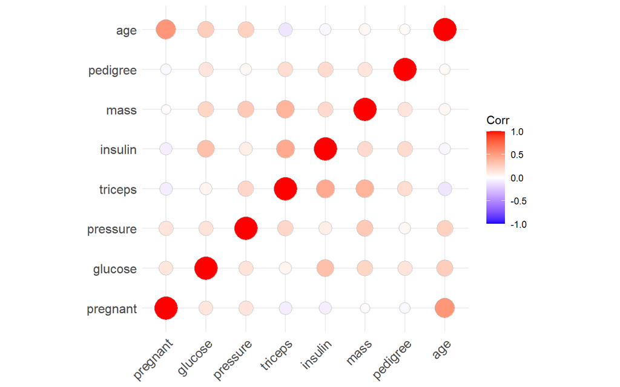

```r
ggcorrplot(corr, method = "circle")
```

I would like to select the variables having the correlation between -0.2 and 0.2. Therefore, I will continue with variables pregnant, glucose,pressure,pedigree.

```r
data<-PimaIndiansDiabetes%>%select(pregnant, glucose,pressure,pedigree,diabetes)
```

Check the existence of missing.

```r
summary(data)
```

```
##     pregnant         glucose         pressure         pedigree      diabetes
##  Min.   : 0.000   Min.   :  0.0   Min.   :  0.00   Min.   :0.0780   0:268
##  1st Qu.: 1.000   1st Qu.: 99.0   1st Qu.: 62.00   1st Qu.:0.2437   1:500
##  Median : 3.000   Median :117.0   Median : 72.00   Median :0.3725
##  Mean   : 3.845   Mean   :120.9   Mean   : 69.11   Mean   :0.4719
##  3rd Qu.: 6.000   3rd Qu.:140.2   3rd Qu.: 80.00   3rd Qu.:0.6262
##  Max.   :17.000   Max.   :199.0   Max.   :122.00   Max.   :2.4200
```

lets divide data into two parts.

```r
set.seed(123)
trainindex<-sample(1:nrow(data),round(0.8*nrow(data)))
train<-data[trainindex,]
test<-data[-trainindex,]
```

```r
dim(train)
```

```
## [1] 614   5
```

```r
dim(test)
```

```
## [1] 154   5
```

```r
library(e1071)
NBclassfier=naiveBayes(diabetes~., data=train)
print(NBclassfier)
```

```
##
## Naive Bayes Classifier for Discrete Predictors
##
## Call:
## naiveBayes.default(x = X, y = Y, laplace = laplace)
##
## A-priori probabilities:
## Y
##         0         1
## 0.3517915 0.6482085
##
## Conditional probabilities:
##    pregnant
## Y       [,1]     [,2]
##   0 4.763889 3.706034
##   1 3.266332 3.014561
##
##    glucose
## Y       [,1]     [,2]
##   0 141.8843 31.83446
##   1 110.4271 25.61237
##
##    pressure
## Y       [,1]     [,2]
##   0 70.43981 20.55319
##   1 67.70101 18.34949
##
##    pedigree
## Y        [,1]      [,2]
##   0 0.5598519 0.3855997
##   1 0.4426256 0.3108266
```

The naiveBayes function assumed gaussian distributions for numeric varibles. Also, the priori are calculated from the porportion of the training data. The prioris are shown when the object is printed. The Y values are the means and standard deviations of the predictors within each class.

Now let us make prediction for the training data and for the test data.

#### Train and Test Performance

#### Train

**NBC**

```r
train_pred<-predict(NBclassfier, newdata = train, type = "class")
```

```r
train_tab = table(predicted = train_pred , actual = train$diabetes)
library(caret)
train_con_mat = confusionMatrix(train_tab)
c(train_con_mat$overall["Accuracy"],
  train_con_mat$byClass["Sensitivity"],
  train_con_mat$byClass["Specificity"])
```

```
##    Accuracy Sensitivity Specificity
##   0.7605863   0.5416667   0.8793970
```

#### Test

**NBC**

```r
test_pred<-predict(NBclassfier, newdata = test[,-5], type = "class")
```

```r
test_tab = table(predicted = test_pred , actual = test$diabetes)
library(caret)
test_con_mat = confusionMatrix(test_tab)
c(test_con_mat$overall["Accuracy"],
  test_con_mat$byClass["Sensitivity"],
  test_con_mat$byClass["Specificity"])
```

```
##    Accuracy Sensitivity Specificity
##   0.7987013   0.5576923   0.9215686
```

### Comparision of Logistic Regression and Naive Bayes Classifier

The main motivation behind developing several methods in data science is to find the best method for both classification and regression problems. Once we have more models, it means we have more alternatives for the best one.

Most of the study shows that the best model changes based on your problem and purpose. So, now we will compare the performance of both logistic regression and NBC for the problem which is predicting default.

Logistic regression is already performed and let me remind you its performance when the threshold value is 0.5.

```r
test_tab = table(predicted = model_glm_pred_test_0.5, actual = default_tst$default)
library(caret)
test_con_mat = confusionMatrix(test_tab, positive = "Yes")
c(test_con_mat$overall["Accuracy"],
  test_con_mat$byClass["Sensitivity"],
  test_con_mat$byClass["Specificity"])
```

```
##    Accuracy Sensitivity Specificity
##   0.9742000   0.3251534   0.9960719
```

Now, perform NBC using the same data set. Firstly, fit the model as described in the previous part.

```r
library(e1071)
NBclassfier=naiveBayes(default~., data=default_trn)
print(NBclassfier)
```

```
##
## Naive Bayes Classifier for Discrete Predictors
##
## Call:
## naiveBayes.default(x = X, y = Y, laplace = laplace)
##
## A-priori probabilities:
## Y
##    No   Yes
## 0.966 0.034
##
## Conditional probabilities:
##      student
## Y            No       Yes
##   No  0.7142857 0.2857143
##   Yes 0.6352941 0.3647059
##
##      balance
## Y          [,1]     [,2]
##   No   801.4812 455.9604
##   Yes 1736.4466 333.8010
##
##      income
## Y         [,1]     [,2]
##   No  33542.36 13227.03
##   Yes 32186.39 13621.00
```

Then, predict the values from fitted model and show its performance.

```r
test_pred<-predict(NBclassfier, newdata = default_tst[,-1], type = "class")
```

```r
test_tab = table(predicted = test_pred , actual = default_tst$default)
library(caret)
test_con_mat = confusionMatrix(test_tab)
c(test_con_mat$overall["Accuracy"],
  test_con_mat$byClass["Sensitivity"],
  test_con_mat$byClass["Specificity"])
```

```
##    Accuracy Sensitivity Specificity
##   0.9726000   0.9948315   0.3128834
```

To download quiz file please [click](https://www.youtube.com/watch?v=te7b_if_bIs&ab_channel=tutunamaynlar)